# New_York_Airbnb_2019

## New York City Airbnb Open Data

In this project, I will explore the NYC Airbnb listings and aim to find out listing that match with upcoming trip

```python
#Import packages and libraries

import pandas as pd
import numpy as np
import matplotlib.pyplot as plt
import seaborn as sns

!pip install geopandas
import geopandas as gpd
```

```python
#Load data

from google.colab import drive
drive.mount ('/content/gdrive')
```

```python
data = pd.read_csv('gdrive/My Drive/dataset/AB_NYC_2019.csv')
```

### First Inspection of Data

```python
data.head(5)
```

|  | id | name | host_id | host_name | neighbourhood_group | neighbourhood | latitude | longitude | room_type | price | minimum_nights | number_of_reviews | last_review | reviews_per_month | calculated_host_listings_count | availability_365 |
| --- | --- | --- | --- | --- | --- | --- | --- | --- | --- | --- | --- | --- | --- | --- | --- | --- |
| 0 | 2539 | Clean & quiet apt home by the park | 2787 | John | Brooklyn | Kensington | 40.64749 | -73.97237 | Private room | 149 | 1 | 9 | 2018-10-19 | 0.21 | 6 | 365 |
| 1 | 2595 | Skylit Midtown Castle | 2845 | Jennifer | Manhattan | Midtown | 40.75362 | -73.98377 | Entire home/apt | 225 | 1 | 45 | 2019-05-21 | 0.38 | 2 | 355 |
| 2 | 3647 | THE VILLAGE OF HARLEM....NEW YORK ! | 4632 | Elisabeth | Manhattan | Harlem | 40.80902 | -73.94190 | Private room | 150 | 3 | 0 | NaN | NaN | 1 | 365 |
| 3 | 3831 | Cozy Entire Floor of Brownstone | 4869 | LisaRoxanne | Brooklyn | Clinton Hill | 40.68514 | -73.95976 | Entire home/apt | 89 | 1 | 270 | 2019-07-05 | 4.64 | 1 | 194 |
| 4 | 5022 | Entire Apt: Spacious Studio/Loft by central park | 7192 | Laura | Manhattan | East Harlem | 40.79851 | -73.94399 | Entire home/apt | 80 | 10 | 9 | 2018-11-19 | 0.10 | 1 | 0 |

```python
data.dtypes, data.columns
```

```
(id                                  int64
 name                               object
 host_id                             int64
 host_name                          object
 neighbourhood_group                object
 neighbourhood                      object
 latitude                          float64
 longitude                         float64
 room_type                          object
 price                               int64
 minimum_nights                      int64
 number_of_reviews                   int64
 last_review                        object
 reviews_per_month                 float64
 calculated_host_listings_count      int64
 availability_365                    int64
 dtype: object,
 Index(['id', 'name', 'host_id', 'host_name', 'neighbourhood_group',
        'neighbourhood', 'latitude', 'longitude', 'room_type', 'price',
        'minimum_nights', 'number_of_reviews', 'last_review',
        'reviews_per_month', 'calculated_host_listings_count',
        'availability_365'],
       dtype='object'))
```

```python
#Change name of 'neighbourhood_group' to 'boroname'

data.rename(columns={'neighbourhood_group':'boroname'}, inplace=True)
```

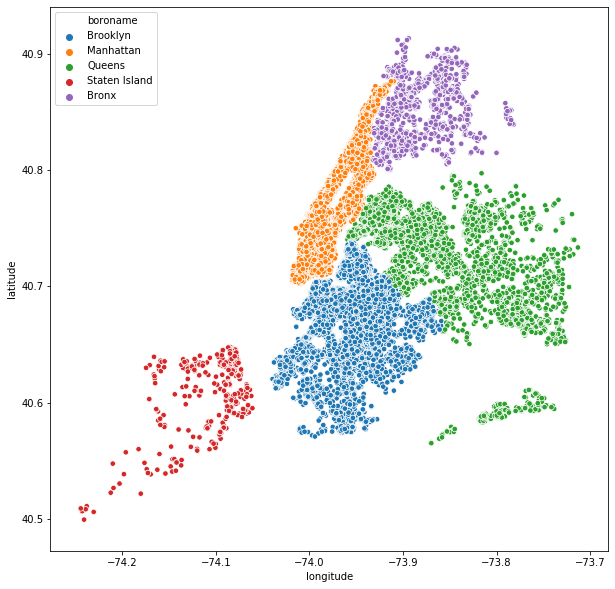

```python
#Find out the listings by borough name
plt.figure(figsize=(10,10))
sns.scatterplot(x='longitude', y='latitude', hue='boroname', s=30, data=data)
```

#### Listing in different Boroughs in NYC

```python
# Count listing by borough

borough_count = data.groupby('boroname').agg('count').reset_index()
borough_count
```

|  | boroname | id | name | host_id | host_name | neighbourhood | latitude | longitude | room_type | price | minimum_nights | number_of_reviews | last_review | reviews_per_month | calculated_host_listings_count | availability_365 |
| --- | --- | --- | --- | --- | --- | --- | --- | --- | --- | --- | --- | --- | --- | --- | --- | --- |
| 0 | Bronx | 1091 | 1090 | 1091 | 1090 | 1091 | 1091 | 1091 | 1091 | 1091 | 1091 | 1091 | 876 | 876 | 1091 | 1091 |
| 1 | Brooklyn | 20104 | 20098 | 20104 | 20095 | 20104 | 20104 | 20104 | 20104 | 20104 | 20104 | 20104 | 16447 | 16447 | 20104 | 20104 |
| 2 | Manhattan | 21661 | 21652 | 21661 | 21652 | 21661 | 21661 | 21661 | 21661 | 21661 | 21661 | 21661 | 16632 | 16632 | 21661 | 21661 |
| 3 | Queens | 5666 | 5666 | 5666 | 5664 | 5666 | 5666 | 5666 | 5666 | 5666 | 5666 | 5666 | 4574 | 4574 | 5666 | 5666 |
| 4 | Staten Island | 373 | 373 | 373 | 373 | 373 | 373 | 373 | 373 | 373 | 373 | 373 | 314 | 314 | 373 | 373 |

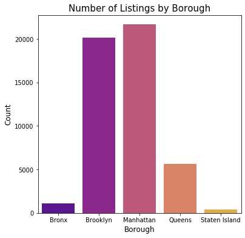

```python
#Plot the count by borough
fig, ax1 = plt.subplots(1,1, figsize=(6,6))
sns.barplot(x='boroname', y='id', data=borough_count, ax=ax1, palette="plasma" )


ax1.set_title('Number of Listings by Borough', fontsize=15)
ax1.set_xlabel('Borough', fontsize=12)
ax1.set_ylabel('Count', fontsize=12)
ax1.tick_params(axis='both', labelsize=10)
```

Manhattan have more listings that other regions

```python
#Using geopandas to bring in a base layer of NYC boroughs

nyc = gpd.read_file(gpd.datasets.get_path('nybb'))
nyc.head(5)
```

|  | BoroCode | BoroName | Shape_Leng | Shape_Area | geometry |
| --- | --- | --- | --- | --- | --- |
| 0 | 5 | Staten Island | 330470.010332 | 1.623820e+09 | MULTIPOLYGON (((970217.022 145643.332, 970227.... |
| 1 | 4 | Queens | 896344.047763 | 3.045213e+09 | MULTIPOLYGON (((1029606.077 156073.814, 102957... |
| 2 | 3 | Brooklyn | 741080.523166 | 1.937479e+09 | MULTIPOLYGON (((1021176.479 151374.797, 102100... |
| 3 | 1 | Manhattan | 359299.096471 | 6.364715e+08 | MULTIPOLYGON (((981219.056 188655.316, 980940.... |
| 4 | 2 | Bronx | 464392.991824 | 1.186925e+09 | MULTIPOLYGON (((1012821.806 229228.265, 101278... |

```python
#Rename the 'BoroName' to 'boroname', this help to join data for the next step
nyc.rename(columns={'BoroName':'boroname'}, inplace=True)
bc_geo = nyc.merge(borough_count,on='boroname')

bc_geo
```

|  | BoroCode | boroname | Shape_Leng | Shape_Area | geometry | id | name | host_id | host_name | neighbourhood | latitude | longitude | room_type | price | minimum_nights | number_of_reviews | last_review | reviews_per_month | calculated_host_listings_count | availability_365 |
| --- | --- | --- | --- | --- | --- | --- | --- | --- | --- | --- | --- | --- | --- | --- | --- | --- | --- | --- | --- | --- |
| 0 | 5 | Staten Island | 330470.010332 | 1.623820e+09 | MULTIPOLYGON (((970217.022 145643.332, 970227.... | 373 | 373 | 373 | 373 | 373 | 373 | 373 | 373 | 373 | 373 | 373 | 314 | 314 | 373 | 373 |
| 1 | 4 | Queens | 896344.047763 | 3.045213e+09 | MULTIPOLYGON (((1029606.077 156073.814, 102957... | 5666 | 5666 | 5666 | 5664 | 5666 | 5666 | 5666 | 5666 | 5666 | 5666 | 5666 | 4574 | 4574 | 5666 | 5666 |
| 2 | 3 | Brooklyn | 741080.523166 | 1.937479e+09 | MULTIPOLYGON (((1021176.479 151374.797, 102100... | 20104 | 20098 | 20104 | 20095 | 20104 | 20104 | 20104 | 20104 | 20104 | 20104 | 20104 | 16447 | 16447 | 20104 | 20104 |
| 3 | 1 | Manhattan | 359299.096471 | 6.364715e+08 | MULTIPOLYGON (((981219.056 188655.316, 980940.... | 21661 | 21652 | 21661 | 21652 | 21661 | 21661 | 21661 | 21661 | 21661 | 21661 | 21661 | 16632 | 16632 | 21661 | 21661 |
| 4 | 2 | Bronx | 464392.991824 | 1.186925e+09 | MULTIPOLYGON (((1012821.806 229228.265, 101278... | 1091 | 1090 | 1091 | 1090 | 1091 | 1091 | 1091 | 1091 | 1091 | 1091 | 1091 | 876 | 876 | 1091 | 1091 |

```
(905464.7390380859, 1075092.8783935546, 112485.76063504723, 280480.4142594267)
```

[figure not shown]

```python
#Plot into the map count listing by borough

fig,ax = plt.subplots(1,1, figsize=(10,10))
bc_geo.plot(column='id', cmap='viridis_r', alpha=.5, ax=ax, legend=True)
bc_geo.apply(lambda x:ax.annotate(s=x.boroname, color='black', xy=x.geometry.centroid.coords[0],ha='center'), axis=1)
plt.title('Number of Airbnb Listings by NYC Borough')
plt.axis('off')
```

We could see that most of listings locate in Brooklyn and Manhattan. In contract, Airbnb is not so popular in Bronx and Staten Island

```python
#import shapely
from shapely import wkt
```

```python
crs = {'init':'epsg:4326'}
geometry = gpd.points_from_xy(data.longitude, data.latitude)
geo_data = gpd.GeoDataFrame(data,crs=crs,geometry=geometry)
```

```
(-74.28337047811617, -73.67222994890714, 40.4751445261289, 40.936503645041604)
```

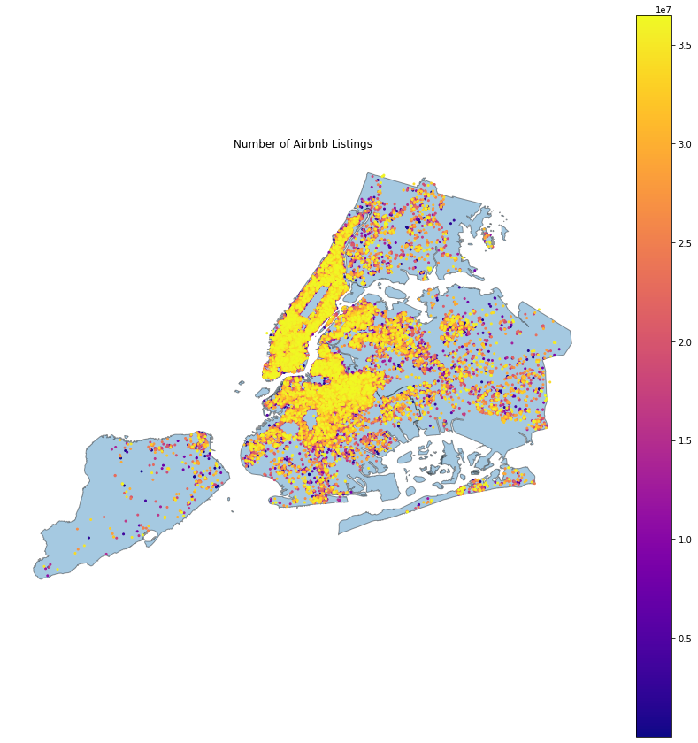

```python
fig,ax = plt.subplots(figsize=(15,15))
nyc.plot(ax=ax,alpha=0.4,edgecolor='black')
geo_data.plot(column='id',ax=ax,legend=True,cmap='plasma',markersize=4)

plt.title("Number of Airbnb Listings")
plt.axis('off')
```

For the upcoming trip, I would like to find 'Entire home/apt' option and prefer if it locate in Brooklyn. So let's plot a map to see locations of room type

```
(-74.28337047811617, -73.67222994890714, 40.4751445261289, 40.936503645041604)
```

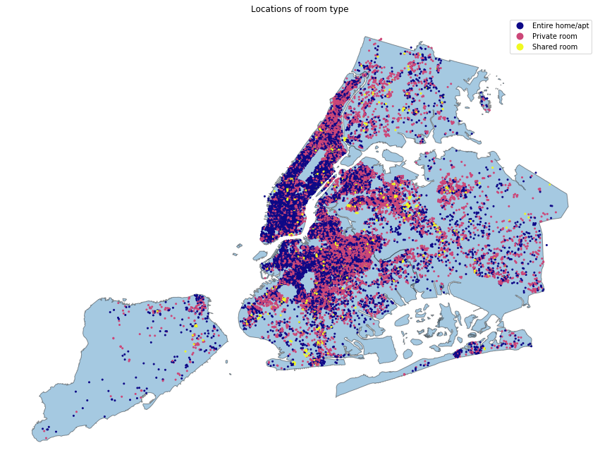

```python
fig,ax = plt.subplots(figsize=(15,15))
nyc.plot(ax=ax, alpha=0.4, edgecolor='black')
geo_data.plot(column='room_type',ax=ax,legend=True,cmap='plasma',markersize=4)
plt.title('Locations of room type')
plt.axis('off')
```

Also find out different room type by borough

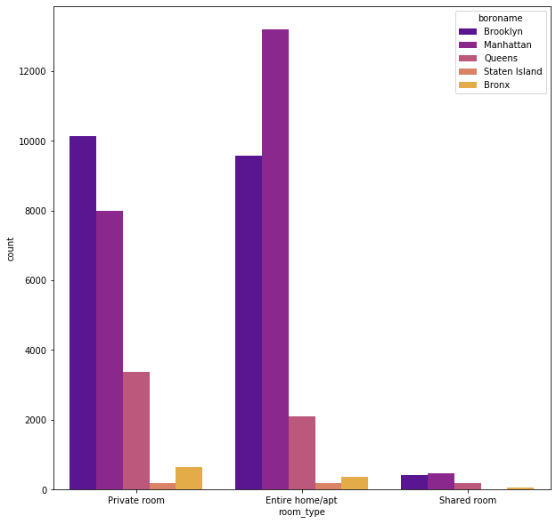

```python
plt.figure(figsize=(10,10))
ax = sns.countplot(data['room_type'], hue=data['boroname'], palette='plasma')
```

Manhattan offer more entire home/apt than other regions. However, I am a student love travelling on budget. Therefore, I will focus on listings in Manhattan which have price under 65

```python
data_manha_65=data[data.boroname=='Manhattan']
data_manha_65.head()
```

|  | id | name | host_id | host_name | boroname | neighbourhood | latitude | longitude | room_type | price | minimum_nights | number_of_reviews | last_review | reviews_per_month | calculated_host_listings_count | availability_365 | geometry |
| --- | --- | --- | --- | --- | --- | --- | --- | --- | --- | --- | --- | --- | --- | --- | --- | --- | --- |
| 1 | 2595 | Skylit Midtown Castle | 2845 | Jennifer | Manhattan | Midtown | 40.75362 | -73.98377 | Entire home/apt | 225 | 1 | 45 | 2019-05-21 | 0.38 | 2 | 355 | POINT (-73.98377 40.75362) |
| 2 | 3647 | THE VILLAGE OF HARLEM....NEW YORK ! | 4632 | Elisabeth | Manhattan | Harlem | 40.80902 | -73.94190 | Private room | 150 | 3 | 0 | NaN | NaN | 1 | 365 | POINT (-73.94190 40.80902) |
| 4 | 5022 | Entire Apt: Spacious Studio/Loft by central park | 7192 | Laura | Manhattan | East Harlem | 40.79851 | -73.94399 | Entire home/apt | 80 | 10 | 9 | 2018-11-19 | 0.10 | 1 | 0 | POINT (-73.94399 40.79851) |
| 5 | 5099 | Large Cozy 1 BR Apartment In Midtown East | 7322 | Chris | Manhattan | Murray Hill | 40.74767 | -73.97500 | Entire home/apt | 200 | 3 | 74 | 2019-06-22 | 0.59 | 1 | 129 | POINT (-73.97500 40.74767) |
| 7 | 5178 | Large Furnished Room Near B'way | 8967 | Shunichi | Manhattan | Hell's Kitchen | 40.76489 | -73.98493 | Private room | 79 | 2 | 430 | 2019-06-24 | 3.47 | 1 | 220 | POINT (-73.98493 40.76489) |

```python
data_manha_65 = data_manha[data_manha.price <65]
data_manha_65['label']=data_manha_65.apply(lambda x: (x['name'],'price:'+str(x['price'])),axis=1)
data_manha_65.head()
```

|  | id | name | host_id | host_name | boroname | neighbourhood | latitude | longitude | room_type | price | minimum_nights | number_of_reviews | last_review | reviews_per_month | calculated_host_listings_count | availability_365 | geometry | label |
| --- | --- | --- | --- | --- | --- | --- | --- | --- | --- | --- | --- | --- | --- | --- | --- | --- | --- | --- |
| 28 | 9518 | SPACIOUS, LOVELY FURNISHED MANHATTAN BEDROOM | 31374 | Shon | Manhattan | Inwood | 40.86482 | -73.92106 | Private room | 44 | 3 | 108 | 2019-06-15 | 1.11 | 3 | 311 | POINT (-73.92106 40.86482) | (SPACIOUS, LOVELY FURNISHED MANHATTAN BEDROOM,... |
| 30 | 9668 | front room/double bed | 32294 | Ssameer Or Trip | Manhattan | Harlem | 40.82245 | -73.95104 | Private room | 50 | 3 | 242 | 2019-06-01 | 2.04 | 3 | 355 | POINT (-73.95104 40.82245) | (front room/double bed, price:50) |
| 31 | 9704 | Spacious 1 bedroom in luxe building | 32045 | Teri | Manhattan | Harlem | 40.81305 | -73.95466 | Private room | 52 | 2 | 88 | 2019-06-14 | 1.42 | 1 | 255 | POINT (-73.95466 40.81305) | (Spacious 1 bedroom in luxe building, price:52) |
| 33 | 9783 | back room/bunk beds | 32294 | Ssameer Or Trip | Manhattan | Harlem | 40.82130 | -73.95318 | Private room | 50 | 3 | 273 | 2019-07-01 | 2.37 | 3 | 359 | POINT (-73.95318 40.82130) | (back room/bunk beds, price:50) |
| 39 | 12048 | LowerEastSide apt share shortterm 1 | 7549 | Ben | Manhattan | Lower East Side | 40.71401 | -73.98917 | Shared room | 40 | 1 | 214 | 2019-07-05 | 1.81 | 4 | 188 | POINT (-73.98917 40.71401) | (LowerEastSide apt share shortterm 1, price:40) |

```python
#install folium to create a map
!pip install git+https://github.com/python-visualization/folium
```

[output not shown]

```python
import folium
from folium import plugins

Long=-73.92
Lat=40.86
manha_map=folium.Map([Lat,Long],zoom_start=12)
manha_rooms_map=plugins.MarkerCluster().add_to(manha_map)
for lat,lon,label in zip(data_manha_65.latitude,data_manha_65.longitude,data_manha_65.label):
    folium.Marker(location=[lat,lon],icon=None,popup=label).add_to(manha_rooms_map)
manha_map.add_child(manha_rooms_map)

manha_map = folium.Map([Lat,Long],zoom_start=12)


manha_map
```

[interactive chart not shown]